# Bank Marketing for Term Deposits

Anush Harish - 21250164

```r
#Packages
library(tidyverse)
```

```r
library(gmodels)
library(ggmosaic)
library(gridExtra)
library(cowplot)
library(ggplot2)
library(dplyr)
library(caret)
library(ROCR)
library(pROC)
library(naivebayes)
library(randomForest)
#Reading data
bank_data <- read.table("/Users/anush/Desktop/MSc DSA /SEM SUM/MSC IN DATA SCIENCE AND ANALYTICS-PROJECT & DISSERTATION/Data/bank-additional/bank-additional-full.csv",sep = ";",header = TRUE)
dim(bank_data)
```

```
## [1] 41188    21
```

```r
Bank_Data<-bank_data
head(Bank_Data)
```

```
##   age       job marital   education default housing loan   contact month
## 1  56 housemaid married    basic.4y      no      no   no telephone   may
## 2  57  services married high.school unknown      no   no telephone   may
## 3  37  services married high.school      no     yes   no telephone   may
## 4  40    admin. married    basic.6y      no      no   no telephone   may
## 5  56  services married high.school      no      no  yes telephone   may
## 6  45  services married    basic.9y unknown      no   no telephone   may
##   day_of_week duration campaign pdays previous    poutcome emp.var.rate
## 1         mon      261        1   999        0 nonexistent          1.1
## 2         mon      149        1   999        0 nonexistent          1.1
## 3         mon      226        1   999        0 nonexistent          1.1
## 4         mon      151        1   999        0 nonexistent          1.1
## 5         mon      307        1   999        0 nonexistent          1.1
## 6         mon      198        1   999        0 nonexistent          1.1
##   cons.price.idx cons.conf.idx euribor3m nr.employed  y
## 1         93.994         -36.4     4.857        5191 no
## 2         93.994         -36.4     4.857        5191 no
## 3         93.994         -36.4     4.857        5191 no
## 4         93.994         -36.4     4.857        5191 no
## 5         93.994         -36.4     4.857        5191 no
## 6         93.994         -36.4     4.857        5191 no
```

```r
dim(Bank_Data)
```

```
## [1] 41188    21
```

```r
names(Bank_Data)
```

```
##  [1] "age"            "job"            "marital"        "education"
##  [5] "default"        "housing"        "loan"           "contact"
##  [9] "month"          "day_of_week"    "duration"       "campaign"
## [13] "pdays"          "previous"       "poutcome"       "emp.var.rate"
## [17] "cons.price.idx" "cons.conf.idx"  "euribor3m"      "nr.employed"
## [21] "y"
```

```r
str(Bank_Data)
```

```
## 'data.frame':    41188 obs. of  21 variables:
##  $ age           : int  56 57 37 40 56 45 59 41 24 25 ...
##  $ job           : chr  "housemaid" "services" "services" "admin." ...
##  $ marital       : chr  "married" "married" "married" "married" ...
##  $ education     : chr  "basic.4y" "high.school" "high.school" "basic.6y" ...
##  $ default       : chr  "no" "unknown" "no" "no" ...
##  $ housing       : chr  "no" "no" "yes" "no" ...
##  $ loan          : chr  "no" "no" "no" "no" ...
##  $ contact       : chr  "telephone" "telephone" "telephone" "telephone" ...
##  $ month         : chr  "may" "may" "may" "may" ...
##  $ day_of_week   : chr  "mon" "mon" "mon" "mon" ...
##  $ duration      : int  261 149 226 151 307 198 139 217 380 50 ...
##  $ campaign      : int  1 1 1 1 1 1 1 1 1 1 ...
##  $ pdays         : int  999 999 999 999 999 999 999 999 999 999 ...
##  $ previous      : int  0 0 0 0 0 0 0 0 0 0 ...
##  $ poutcome      : chr  "nonexistent" "nonexistent" "nonexistent" "nonexistent" ...
##  $ emp.var.rate  : num  1.1 1.1 1.1 1.1 1.1 1.1 1.1 1.1 1.1 1.1 ...
##  $ cons.price.idx: num  94 94 94 94 94 ...
##  $ cons.conf.idx : num  -36.4 -36.4 -36.4 -36.4 -36.4 -36.4 -36.4 -36.4 -36.4 -36.4 ...
##  $ euribor3m     : num  4.86 4.86 4.86 4.86 4.86 ...
##  $ nr.employed   : num  5191 5191 5191 5191 5191 ...
##  $ y             : chr  "no" "no" "no" "no" ...
```

```r
# table(Bank_Data$age)
# table(Bank_Data$job)
# table(Bank_Data$marital)
# table(Bank_Data$education)
# table(Bank_Data$default)
# table(Bank_Data$housing)
# table(Bank_Data$loan)
# table(Bank_Data$contact)
# table(Bank_Data$month)
# table(Bank_Data$day_of_week)
# table(Bank_Data$duration)
# table(Bank_Data$campaign)
# table(Bank_Data$pdays)
# table(Bank_Data$previous)
# table(Bank_Data$poutcome)
# table(Bank_Data$emp.var.rate)
# table(Bank_Data$cons.price.idx)
# table(Bank_Data$cons.conf.idx)
# table(Bank_Data$euribor3m)
# table(Bank_Data$nr.employed)
# table(bank_data$y)
```

# Exploratory Analysis and Feature Engineering

```r
#Unknowns
colSums(Bank_Data == "unknown")
```

```
##            age            job        marital      education        default
##              0            330             80           1731           8597
##        housing           loan        contact          month    day_of_week
##            990            990              0              0              0
##       duration       campaign          pdays       previous       poutcome
##              0              0              0              0              0
##   emp.var.rate cons.price.idx  cons.conf.idx      euribor3m    nr.employed
##              0              0              0              0              0
##              y
##              0
```

```r
sum(Bank_Data == "unknown")
```

```
## [1] 12718
```

```r
unknowns<-Bank_Data %>%
  summarise_all(list(~sum(. == "unknown"))) %>%
  gather(key = "Variables", value = "Number_of_Unknowns") %>%
  arrange(-Number_of_Unknowns)
unknowns
```

```
##         Variables Number_of_Unknowns
## 1         default               8597
## 2       education               1731
## 3         housing                990
## 4            loan                990
## 5             job                330
## 6         marital                 80
## 7             age                  0
## 8         contact                  0
## 9           month                  0
## 10    day_of_week                  0
## 11       duration                  0
## 12       campaign                  0
## 13          pdays                  0
## 14       previous                  0
## 15       poutcome                  0
## 16   emp.var.rate                  0
## 17 cons.price.idx                  0
## 18  cons.conf.idx                  0
## 19      euribor3m                  0
## 20    nr.employed                  0
## 21              y                  0
```

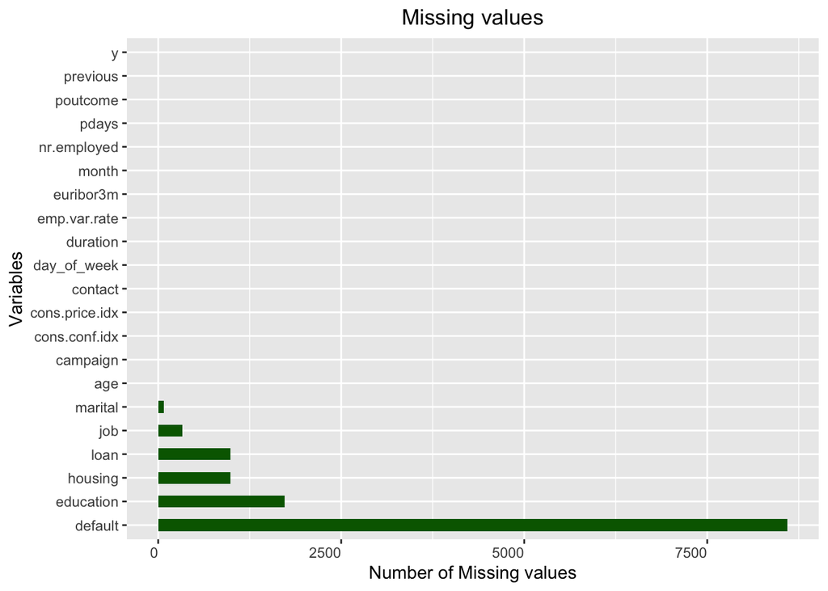

```r
ggplot(data=unknowns, aes(x=reorder(Variables,-Number_of_Unknowns), y=Number_of_Unknowns)) +
  geom_bar(width=0.5, stat="identity", fill="darkgreen") +
  labs(title="Missing values",x="Variables", y="Number of Missing values" )+theme(plot.title = element_text(hjust = 0.5), axis.text.x = element_text( hjust = 1))+coord_flip()
```

## Bank Client Data

#### 1. AGE

```r
table(bank_data$age)
```

```
##
##   17   18   19   20   21   22   23   24   25   26   27   28   29   30   31   32
##    5   28   42   65  102  137  226  463  598  698  851 1001 1453 1714 1947 1846
##   33   34   35   36   37   38   39   40   41   42   43   44   45   46   47   48
## 1833 1745 1759 1780 1475 1407 1432 1161 1278 1142 1055 1011 1103 1030  928  979
##   49   50   51   52   53   54   55   56   57   58   59   60   61   62   63   64
##  839  875  754  779  733  684  648  704  646  576  463  283   73   62   55   57
##   65   66   67   68   69   70   71   72   73   74   75   76   77   78   79   80
##   44   57   26   33   34   47   53   34   34   32   24   34   20   27   14   31
##   81   82   83   84   85   86   87   88   89   91   92   94   95   98
##   20   17   17    7   15    8    1   22    2    2    4    1    1    2
```

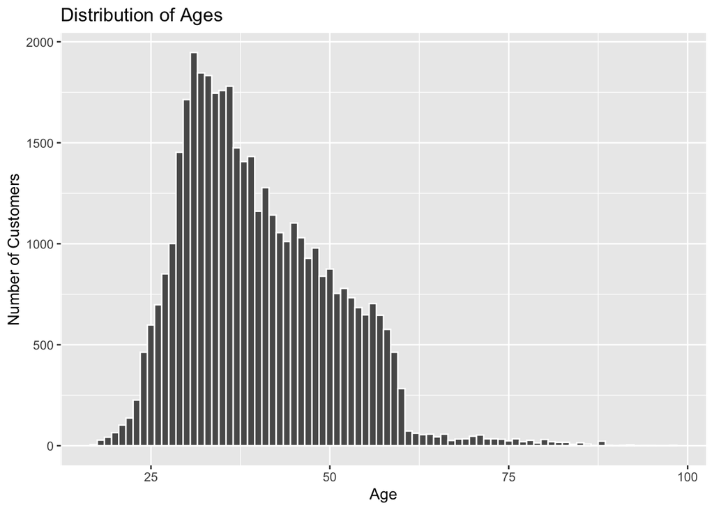

```r
Age_plot <- ggplot(bank_data, aes(x = age, fill = age)) +
                     geom_histogram(binwidth = 1,color="white") +
                     labs(x = "Age",y = 'Number of Customers',
                          title = 'Distribution of Ages')

Age_plot
```

```r
summary(bank_data$age)
```

```
##    Min. 1st Qu.  Median    Mean 3rd Qu.    Max.
##   17.00   32.00   38.00   40.02   47.00   98.00
```

The distribution of age is from 17 to 98. 50% of customers are between the ages of 32 and 47. With an average of 40 and median of 38. Customers aged below 30 are categorized as Young_aged, ages from 30 to 60 are categorized as Middle aged, and customers aged above 60 are categorized as Old_age. So, variable age is converted from numerical to categorical.

```r
#Converting age from continuous to categorical
Bank_Data<-bank_data %>%
  mutate(age = if_else(age < 30, "Young_aged", if_else(age > 60, "Old_aged", "Middle_aged")))
CrossTable(Bank_Data$age,Bank_Data$y)
```

```
##
##
##    Cell Contents
## |-------------------------|
## |                       N |
## | Chi-square contribution |
## |           N / Row Total |
## |           N / Col Total |
## |         N / Table Total |
## |-------------------------|
##
##
## Total Observations in Table:  41188
##
##
##               | Bank_Data$y
## Bank_Data$age |        no |       yes | Row Total |
## --------------|-----------|-----------|-----------|
##   Middle_aged |     31305 |      3304 |     34609 |
##               |    11.522 |    90.756 |           |
##               |     0.905 |     0.095 |     0.840 |
##               |     0.857 |     0.712 |           |
##               |     0.760 |     0.080 |           |
## --------------|-----------|-----------|-----------|
##      Old_aged |       496 |       414 |       910 |
##               |   120.154 |   946.422 |           |
##               |     0.545 |     0.455 |     0.022 |
##               |     0.014 |     0.089 |           |
##               |     0.012 |     0.010 |           |
## --------------|-----------|-----------|-----------|
##    Young_aged |      4747 |       922 |      5669 |
##               |    15.962 |   125.729 |           |
##               |     0.837 |     0.163 |     0.138 |
##               |     0.130 |     0.199 |           |
##               |     0.115 |     0.022 |           |
## --------------|-----------|-----------|-----------|
##  Column Total |     36548 |      4640 |     41188 |
##               |     0.887 |     0.113 |           |
## --------------|-----------|-----------|-----------|
##
##
```

```r
#Chi-sq test for age vs y
chisq.test(Bank_Data$age,Bank_Data$y)
```

```
##
##  Pearson's Chi-squared test
##
## data:  Bank_Data$age and Bank_Data$y
## X-squared = 1310.5, df = 2, p-value < 2.2e-16
```

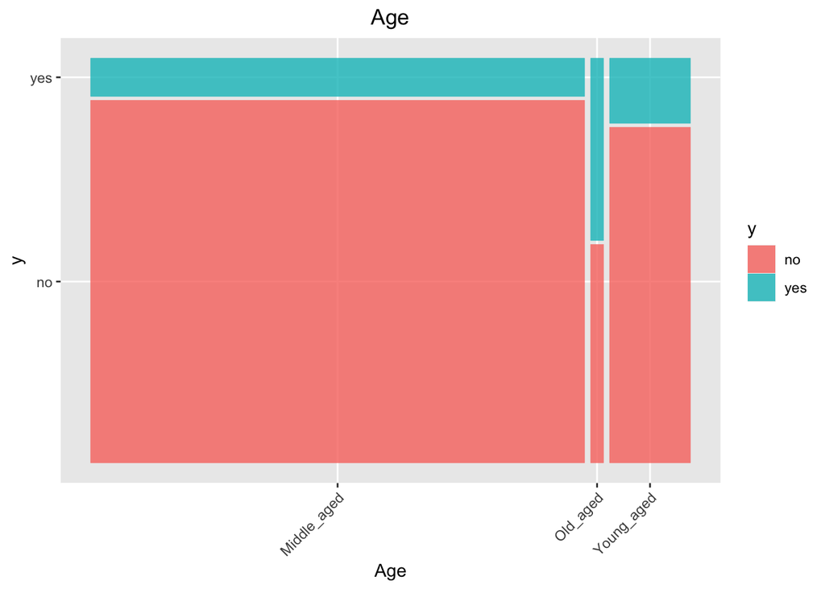

```r
ggplot(Bank_Data) +
  geom_mosaic(aes(x = product(y, age), fill = y)) +labs(title="Age",x="Age")+theme(plot.title = element_text(hjust = 0.5), axis.text.x = element_text(angle = 45, hjust = 1))
```

Since p-value is less than 0.05. It can be concluded that variable age is significant with the response variable i.e., y.The percentage of people over 60 who subscribe to a term deposit is nearly 45.5%, which is higher than the percentage of younger individuals is 16.3% and the percentage of people aged 30 to 60 is 9.5%.

#### 2. JOB

```r
table(Bank_Data$job)
```

```
##
##        admin.   blue-collar  entrepreneur     housemaid    management
##         10422          9254          1456          1060          2924
##       retired self-employed      services       student    technician
##          1720          1421          3969           875          6743
##    unemployed       unknown
##          1014           330
```

```r
CrossTable(Bank_Data$job,Bank_Data$y)
```

```
##
##
##    Cell Contents
## |-------------------------|
## |                       N |
## | Chi-square contribution |
## |           N / Row Total |
## |           N / Col Total |
## |         N / Table Total |
## |-------------------------|
##
##
## Total Observations in Table:  41188
##
##
##               | Bank_Data$y
## Bank_Data$job |        no |       yes | Row Total |
## --------------|-----------|-----------|-----------|
##        admin. |      9070 |      1352 |     10422 |
##               |     3.423 |    26.961 |           |
##               |     0.870 |     0.130 |     0.253 |
##               |     0.248 |     0.291 |           |
##               |     0.220 |     0.033 |           |
## --------------|-----------|-----------|-----------|
##   blue-collar |      8616 |       638 |      9254 |
##               |    19.926 |   156.951 |           |
##               |     0.931 |     0.069 |     0.225 |
##               |     0.236 |     0.138 |           |
##               |     0.209 |     0.015 |           |
## --------------|-----------|-----------|-----------|
##  entrepreneur |      1332 |       124 |      1456 |
##               |     1.240 |     9.767 |           |
##               |     0.915 |     0.085 |     0.035 |
##               |     0.036 |     0.027 |           |
##               |     0.032 |     0.003 |           |
## --------------|-----------|-----------|-----------|
##     housemaid |       954 |       106 |      1060 |
##               |     0.191 |     1.507 |           |
##               |     0.900 |     0.100 |     0.026 |
##               |     0.026 |     0.023 |           |
```

[output cut: 40 more lines]

```
##               |     0.858 |     0.142 |     0.025 |
##               |     0.024 |     0.031 |           |
##               |     0.021 |     0.003 |           |
## --------------|-----------|-----------|-----------|
##       unknown |       293 |        37 |       330 |
##               |     0.000 |     0.001 |           |
##               |     0.888 |     0.112 |     0.008 |
##               |     0.008 |     0.008 |           |
##               |     0.007 |     0.001 |           |
## --------------|-----------|-----------|-----------|
##  Column Total |     36548 |      4640 |     41188 |
##               |     0.887 |     0.113 |           |
## --------------|-----------|-----------|-----------|
##
##
```

```r
chisq.test(Bank_Data$job,Bank_Data$y)
```

```
##
##  Pearson's Chi-squared test
##
## data:  Bank_Data$job and Bank_Data$y
## X-squared = 961.24, df = 11, p-value < 2.2e-16
```

The “unknown” level in the data with a proportion of 0.008 so it should be removed because it doesn’t provide any significant information. Rows with this value in the “job” column will be eliminated. Job variable is significant with the response variable because its p-value is less than 0.05.

```r
#Remove Unknowns
Bank_Data<-Bank_Data %>% filter(job != "unknown")
```

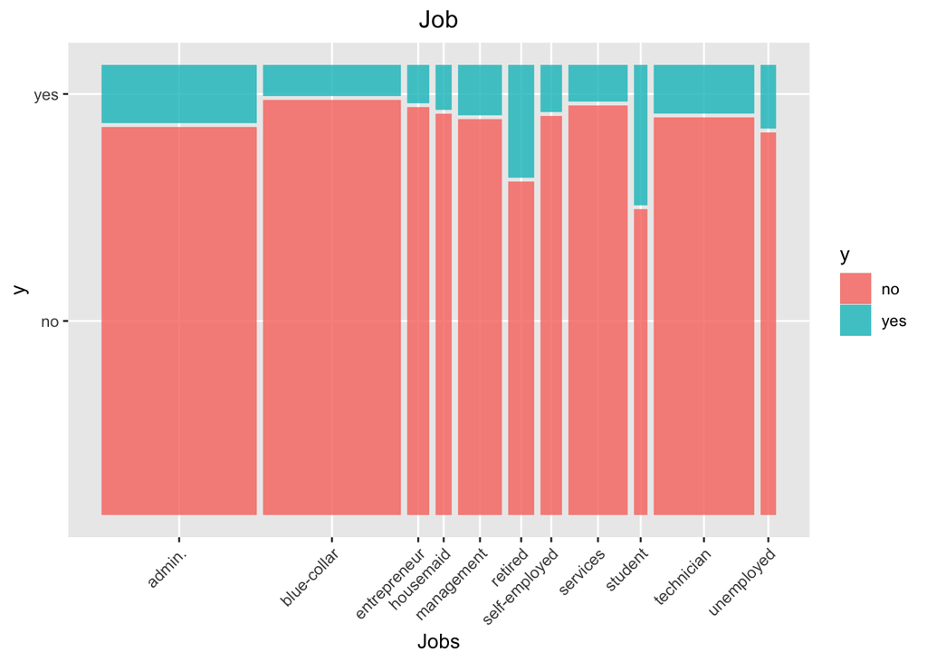

```r
ggplot(Bank_Data) +
  geom_mosaic(aes(x = product(y, job), fill = y)) +labs(title="Job",x="Jobs")+theme(plot.title = element_text(hjust = 0.5), axis.text.x = element_text(angle = 45, hjust = 1))
```

With 31.4%, students show the best relative frequency of term deposit subscription. Term deposit subscriptions are highest among retired people with 25.2% and unemployed with 14.2%.

#### 3. Marital

```r
table(Bank_Data$marital)
```

```
##
## divorced  married   single  unknown
##     4599    24694    11494       71
```

```r
CrossTable(Bank_Data$marital,Bank_Data$y)
```

```
##
##
##    Cell Contents
## |-------------------------|
## |                       N |
## | Chi-square contribution |
## |           N / Row Total |
## |           N / Col Total |
## |         N / Table Total |
## |-------------------------|
##
##
## Total Observations in Table:  40858
##
##
##                   | Bank_Data$y
## Bank_Data$marital |        no |       yes | Row Total |
## ------------------|-----------|-----------|-----------|
##          divorced |      4126 |       473 |      4599 |
##                   |     0.499 |     3.929 |           |
##                   |     0.897 |     0.103 |     0.113 |
##                   |     0.114 |     0.103 |           |
##                   |     0.101 |     0.012 |           |
## ------------------|-----------|-----------|-----------|
##           married |     22178 |      2516 |     24694 |
##                   |     3.229 |    25.431 |           |
##                   |     0.898 |     0.102 |     0.604 |
##                   |     0.612 |     0.547 |           |
##                   |     0.543 |     0.062 |           |
## ------------------|-----------|-----------|-----------|
##            single |      9889 |      1605 |     11494 |
##                   |     9.429 |    74.264 |           |
##                   |     0.860 |     0.140 |     0.281 |
##                   |     0.273 |     0.349 |           |
##                   |     0.242 |     0.039 |           |
## ------------------|-----------|-----------|-----------|
##           unknown |        62 |         9 |        71 |
##                   |     0.016 |     0.125 |           |
##                   |     0.873 |     0.127 |     0.002 |
##                   |     0.002 |     0.002 |           |
##                   |     0.002 |     0.000 |           |
## ------------------|-----------|-----------|-----------|
##      Column Total |     36255 |      4603 |     40858 |
##                   |     0.887 |     0.113 |           |
## ------------------|-----------|-----------|-----------|
##
##
```

```r
chisq.test(Bank_Data$marital,Bank_Data$y)
```

```
##
##  Pearson's Chi-squared test
##
## data:  Bank_Data$marital and Bank_Data$y
## X-squared = 116.92, df = 3, p-value < 2.2e-16
```

The “unknown” level in the data with a proportion of 0.002. So, it should be removed because it doesn’t provide any significant information. Rows with this value in the “marital” column will be eliminated. Marital variable is significant with the response variable because its p-value is less than 0.05.

```r
#Remove Unknowns
Bank_Data<-Bank_Data %>% filter(marital != "unknown")
```

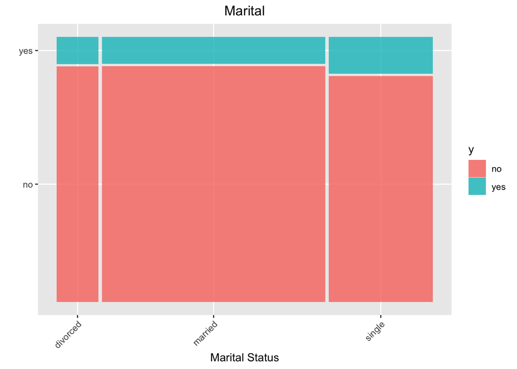

```r
ggplot(Bank_Data) +
  geom_mosaic(aes(x = product(y, marital), fill = y))  +labs(title="Marital",x="Marital Status", y=" " )+theme(plot.title = element_text(hjust = 0.5), axis.text.x = element_text(angle = 45, hjust = 1))
```

Single’s show a high subscription rate of 14%. Both married and divorced have almost the same subscription rate of 10%

#### 4. Education

```r
table(Bank_Data$education)
```

```
##
##            basic.4y            basic.6y            basic.9y         high.school
##                4118                2264                6006                9464
##          illiterate professional.course   university.degree             unknown
##                  18                5225               12096                1596
```

```r
CrossTable(Bank_Data$education,Bank_Data$y)
```

```
##
##
##    Cell Contents
## |-------------------------|
## |                       N |
## | Chi-square contribution |
## |           N / Row Total |
## |           N / Col Total |
## |         N / Table Total |
## |-------------------------|
##
##
## Total Observations in Table:  40787
##
##
##                     | Bank_Data$y
## Bank_Data$education |        no |       yes | Row Total |
## --------------------|-----------|-----------|-----------|
##            basic.4y |      3695 |       423 |      4118 |
##                     |     0.456 |     3.594 |           |
##                     |     0.897 |     0.103 |     0.101 |
##                     |     0.102 |     0.092 |           |
##                     |     0.091 |     0.010 |           |
## --------------------|-----------|-----------|-----------|
##            basic.6y |      2077 |       187 |      2264 |
##                     |     2.302 |    18.135 |           |
##                     |     0.917 |     0.083 |     0.056 |
##                     |     0.057 |     0.041 |           |
##                     |     0.051 |     0.005 |           |
## --------------------|-----------|-----------|-----------|
##            basic.9y |      5536 |       470 |      6006 |
##                     |     8.000 |    63.023 |           |
##                     |     0.922 |     0.078 |     0.147 |
##                     |     0.153 |     0.102 |           |
##                     |     0.136 |     0.012 |           |
## --------------------|-----------|-----------|-----------|
##         high.school |      8436 |      1028 |      9464 |
##                     |     0.172 |     1.352 |           |
##                     |     0.891 |     0.109 |     0.232 |
##                     |     0.233 |     0.224 |           |
```

[output cut: 16 more lines]

```
##                     |     0.863 |     0.137 |     0.297 |
##                     |     0.289 |     0.360 |           |
##                     |     0.256 |     0.041 |           |
## --------------------|-----------|-----------|-----------|
##             unknown |      1362 |       234 |      1596 |
##                     |     2.077 |    16.364 |           |
##                     |     0.853 |     0.147 |     0.039 |
##                     |     0.038 |     0.051 |           |
##                     |     0.033 |     0.006 |           |
## --------------------|-----------|-----------|-----------|
##        Column Total |     36193 |      4594 |     40787 |
##                     |     0.887 |     0.113 |           |
## --------------------|-----------|-----------|-----------|
##
##
```

```r
chisq.test(Bank_Data$education,Bank_Data$y)
```

```
##
##  Pearson's Chi-squared test
##
## data:  Bank_Data$education and Bank_Data$y
## X-squared = 188.02, df = 7, p-value < 2.2e-16
```

The “unknown” level contribution for subscription is high. So, the unknown level was changed to university.degree because it was the highest contribution of 29.7%. And illiterate level in the data with a proportion of 0.000. So, it should be removed because it doesn’t provide any significant information. Rows with illiterate value in the “education” column will be eliminated. An education variable is significant with the response variable because its p-value is less than 0.05.

```r
Bank_Data<-Bank_Data %>% filter(education != "illiterate")
Bank_Data<-Bank_Data %>% mutate(education = recode(education, "unknown" = "university.degree"))
```

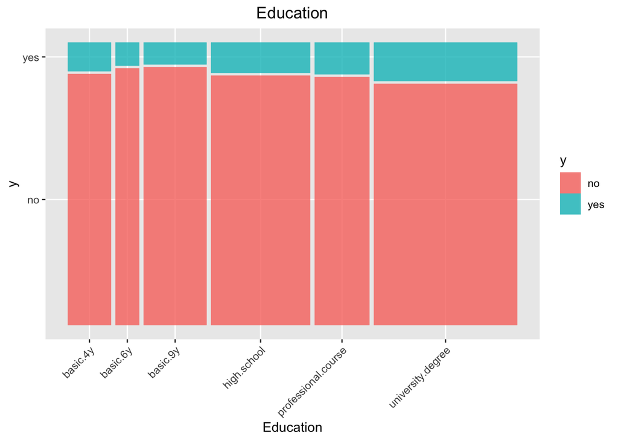

```r
ggplot(Bank_Data) +
  geom_mosaic(aes(x = product(y, education), fill = y)) +labs(title="Education",x="Education")+theme(plot.title = element_text(hjust = 0.5), axis.text.x = element_text(angle = 45, hjust = 1))
```

#### 5. Defalut

```r
table(Bank_Data$default)
```

```
##
##      no unknown     yes
##   32337    8429       3
```

```r
CrossTable(Bank_Data$default,Bank_Data$y)
```

```
##
##
##    Cell Contents
## |-------------------------|
## |                       N |
## | Chi-square contribution |
## |           N / Row Total |
## |           N / Col Total |
## |         N / Table Total |
## |-------------------------|
##
##
## Total Observations in Table:  40769
##
##
##                   | Bank_Data$y
## Bank_Data$default |        no |       yes | Row Total |
## ------------------|-----------|-----------|-----------|
##                no |     28182 |      4155 |     32337 |
##                   |     9.218 |    72.659 |           |
##                   |     0.872 |     0.128 |     0.793 |
##                   |     0.779 |     0.905 |           |
##                   |     0.691 |     0.102 |           |
## ------------------|-----------|-----------|-----------|
##           unknown |      7994 |       435 |      8429 |
##                   |    35.318 |   278.381 |           |
##                   |     0.948 |     0.052 |     0.207 |
##                   |     0.221 |     0.095 |           |
##                   |     0.196 |     0.011 |           |
## ------------------|-----------|-----------|-----------|
##               yes |         3 |         0 |         3 |
##                   |     0.043 |     0.338 |           |
##                   |     1.000 |     0.000 |     0.000 |
##                   |     0.000 |     0.000 |           |
##                   |     0.000 |     0.000 |           |
## ------------------|-----------|-----------|-----------|
##      Column Total |     36179 |      4590 |     40769 |
##                   |     0.887 |     0.113 |           |
## ------------------|-----------|-----------|-----------|
##
##
```

```r
chisq.test(Bank_Data$default,Bank_Data$y)
```

```
##
##  Pearson's Chi-squared test
##
## data:  Bank_Data$default and Bank_Data$y
## X-squared = 395.96, df = 2, p-value < 2.2e-16
```

```r
Bank_Data<-Bank_Data %>% select(-default)
```

#### 6. Housing

```r
table(Bank_Data$housing)
```

```
##
##      no unknown     yes
##   18419     984   21366
```

```r
CrossTable(Bank_Data$housing,Bank_Data$y)
```

```
##
##
##    Cell Contents
## |-------------------------|
## |                       N |
## | Chi-square contribution |
## |           N / Row Total |
## |           N / Col Total |
## |         N / Table Total |
## |-------------------------|
##
##
## Total Observations in Table:  40769
##
##
##                   | Bank_Data$y
## Bank_Data$housing |        no |       yes | Row Total |
## ------------------|-----------|-----------|-----------|
##                no |     16416 |      2003 |     18419 |
##                   |     0.306 |     2.411 |           |
##                   |     0.891 |     0.109 |     0.452 |
##                   |     0.454 |     0.436 |           |
##                   |     0.403 |     0.049 |           |
## ------------------|-----------|-----------|-----------|
##           unknown |       877 |       107 |       984 |
##                   |     0.016 |     0.129 |           |
##                   |     0.891 |     0.109 |     0.024 |
##                   |     0.024 |     0.023 |           |
##                   |     0.022 |     0.003 |           |
## ------------------|-----------|-----------|-----------|
##               yes |     18886 |      2480 |     21366 |
##                   |     0.293 |     2.307 |           |
##                   |     0.884 |     0.116 |     0.524 |
##                   |     0.522 |     0.540 |           |
##                   |     0.463 |     0.061 |           |
## ------------------|-----------|-----------|-----------|
##      Column Total |     36179 |      4590 |     40769 |
##                   |     0.887 |     0.113 |           |
## ------------------|-----------|-----------|-----------|
##
##
```

```r
chisq.test(Bank_Data$housing,Bank_Data$y)
```

```
##
##  Pearson's Chi-squared test
##
## data:  Bank_Data$housing and Bank_Data$y
## X-squared = 5.4627, df = 2, p-value = 0.06513
```

```r
Bank_Data<-Bank_Data %>% select(-housing)
```

Since p-value is greater than 0.05, the housing variable is not significant for the response variable y. So, housing is removed from the dataset.

#### 7. Loan

```r
table(Bank_Data$loan)
```

```
##
##      no unknown     yes
##   33605     984    6180
```

```r
CrossTable(Bank_Data$loan,Bank_Data$y)
```

```
##
##
##    Cell Contents
## |-------------------------|
## |                       N |
## | Chi-square contribution |
## |           N / Row Total |
## |           N / Col Total |
## |         N / Table Total |
## |-------------------------|
##
##
## Total Observations in Table:  40769
##
##
##                | Bank_Data$y
## Bank_Data$loan |        no |       yes | Row Total |
## ---------------|-----------|-----------|-----------|
##             no |     29799 |      3806 |     33605 |
##                |     0.017 |     0.135 |           |
##                |     0.887 |     0.113 |     0.824 |
##                |     0.824 |     0.829 |           |
##                |     0.731 |     0.093 |           |
## ---------------|-----------|-----------|-----------|
##        unknown |       877 |       107 |       984 |
##                |     0.016 |     0.129 |           |
##                |     0.891 |     0.109 |     0.024 |
##                |     0.024 |     0.023 |           |
##                |     0.022 |     0.003 |           |
## ---------------|-----------|-----------|-----------|
##            yes |      5503 |       677 |      6180 |
##                |     0.064 |     0.507 |           |
##                |     0.890 |     0.110 |     0.152 |
##                |     0.152 |     0.147 |           |
##                |     0.135 |     0.017 |           |
## ---------------|-----------|-----------|-----------|
##   Column Total |     36179 |      4590 |     40769 |
##                |     0.887 |     0.113 |           |
## ---------------|-----------|-----------|-----------|
##
##
```

```r
chisq.test(Bank_Data$loan,Bank_Data$y)
```

```
##
##  Pearson's Chi-squared test
##
## data:  Bank_Data$loan and Bank_Data$y
## X-squared = 0.86841, df = 2, p-value = 0.6478
```

```r
Bank_Data<-Bank_Data %>% select(-loan)
```

Since p-value is greater than 0.05, the loan variable is not significant for the response variable y. So, the loan variable is removed from the dataset.

## Last contact of the current campaign

#### 1. Contact

```r
table(Bank_Data$contact)
```

```
##
##  cellular telephone
##     25913     14856
```

```r
CrossTable(Bank_Data$contact,Bank_Data$y)
```

```
##
##
##    Cell Contents
## |-------------------------|
## |                       N |
## | Chi-square contribution |
## |           N / Row Total |
## |           N / Col Total |
## |         N / Table Total |
## |-------------------------|
##
##
## Total Observations in Table:  40769
##
##
##                   | Bank_Data$y
## Bank_Data$contact |        no |       yes | Row Total |
## ------------------|-----------|-----------|-----------|
##          cellular |     22098 |      3815 |     25913 |
##                   |    35.034 |   276.145 |           |
##                   |     0.853 |     0.147 |     0.636 |
##                   |     0.611 |     0.831 |           |
##                   |     0.542 |     0.094 |           |
## ------------------|-----------|-----------|-----------|
##         telephone |     14081 |       775 |     14856 |
##                   |    61.110 |   481.674 |           |
##                   |     0.948 |     0.052 |     0.364 |
##                   |     0.389 |     0.169 |           |
##                   |     0.345 |     0.019 |           |
## ------------------|-----------|-----------|-----------|
##      Column Total |     36179 |      4590 |     40769 |
##                   |     0.887 |     0.113 |           |
## ------------------|-----------|-----------|-----------|
##
##
```

```r
chisq.test(Bank_Data$contact,Bank_Data$y)
```

```
##
##  Pearson's Chi-squared test with Yates' continuity correction
##
## data:  Bank_Data$contact and Bank_Data$y
## X-squared = 853.01, df = 1, p-value < 2.2e-16
```

Since p-value is less than 0.05. It can be concluded that variable contact is significant with the response variable i.e., y.

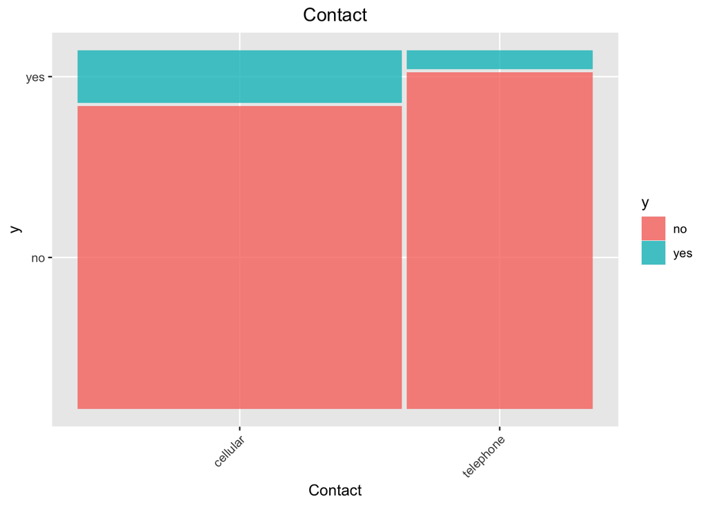

```r
ggplot(Bank_Data) +
  geom_mosaic(aes(x = product(y, contact), fill = y)) +labs(title="Contact",x="Contact")+theme(plot.title = element_text(hjust = 0.5), axis.text.x = element_text(angle = 45, hjust = 1))
```

The percentage of cellular responders who subscribed to term deposits was nearly 14.7%, and the percentage of telephone responders was 5.2%

#### 2. Month

```r
table(Bank_Data$month)
```

```
##
##   apr   aug   dec   jul   jun   mar   may   nov   oct   sep
##  2618  6103   180  7113  5245   541 13616  4084   707   562
```

```r
Bank_Data$month <- factor(Bank_Data$month,levels=c("jan","feb","mar","apr","may","jun","jul","aug","sep","oct","nov","dec"))
CrossTable(Bank_Data$month,Bank_Data$y)
```

```
##
##
##    Cell Contents
## |-------------------------|
## |                       N |
## | Chi-square contribution |
## |           N / Row Total |
## |           N / Col Total |
## |         N / Table Total |
## |-------------------------|
##
##
## Total Observations in Table:  40769
##
##
##                 | Bank_Data$y
## Bank_Data$month |        no |       yes | Row Total |
## ----------------|-----------|-----------|-----------|
##             mar |       267 |       274 |       541 |
##                 |    94.582 |   745.506 |           |
##                 |     0.494 |     0.506 |     0.013 |
##                 |     0.007 |     0.060 |           |
##                 |     0.007 |     0.007 |           |
## ----------------|-----------|-----------|-----------|
##             apr |      2082 |       536 |      2618 |
##                 |    25.052 |   197.463 |           |
##                 |     0.795 |     0.205 |     0.064 |
##                 |     0.058 |     0.117 |           |
##                 |     0.051 |     0.013 |           |
## ----------------|-----------|-----------|-----------|
##             may |     12734 |       882 |     13616 |
##                 |    35.070 |   276.428 |           |
##                 |     0.935 |     0.065 |     0.334 |
##                 |     0.352 |     0.192 |           |
##                 |     0.312 |     0.022 |           |
## ----------------|-----------|-----------|-----------|
##             jun |      4697 |       548 |      5245 |
##                 |     0.388 |     3.060 |           |
##                 |     0.896 |     0.104 |     0.129 |
##                 |     0.130 |     0.119 |           |
```

[output cut: 28 more lines]

```
##                 |     0.899 |     0.101 |     0.100 |
##                 |     0.101 |     0.090 |           |
##                 |     0.090 |     0.010 |           |
## ----------------|-----------|-----------|-----------|
##             dec |        92 |        88 |       180 |
##                 |    28.722 |   226.395 |           |
##                 |     0.511 |     0.489 |     0.004 |
##                 |     0.003 |     0.019 |           |
##                 |     0.002 |     0.002 |           |
## ----------------|-----------|-----------|-----------|
##    Column Total |     36179 |      4590 |     40769 |
##                 |     0.887 |     0.113 |           |
## ----------------|-----------|-----------|-----------|
##
##
```

```r
chisq.test(Bank_Data$month,Bank_Data$y)
```

```
##
##  Pearson's Chi-squared test
##
## data:  Bank_Data$month and Bank_Data$y
## X-squared = 3076, df = 9, p-value < 2.2e-16
```

Since p-value is less than 0.05, it can be concluded that variable month is significant with the response variable i.e., y.

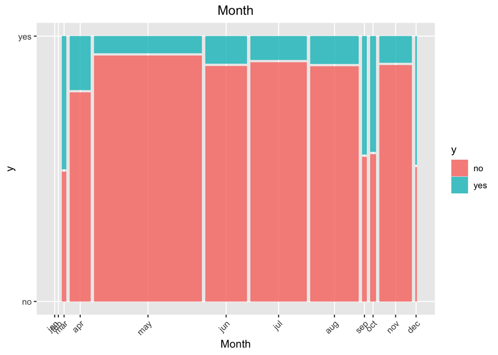

```r
ggplot(Bank_Data) +
  geom_mosaic(aes(x = product(y, month), fill = y)) +labs(title="Month",x="Month")+theme(plot.title = element_text(hjust = 0.5), axis.text.x = element_text(angle = 45, hjust = 1))
```

It can be observed that there was no communication during January and February. The results are very strong for months with very low contact frequency, such as March, September, October, and December, with 44% to 51% of subscribers.

#### 3. Day of the week

```r
table(Bank_Data$day_of_week)
```

```
##
##  fri  mon  thu  tue  wed
## 7775 8419 8524 8001 8050
```

```r
Bank_Data$day_of_week <- factor(Bank_Data$day_of_week,levels=c("mon","tue","wed","thu","fri","sat","sun"))
CrossTable(Bank_Data$day_of_week,Bank_Data$y)
```

```
##
##
##    Cell Contents
## |-------------------------|
## |                       N |
## | Chi-square contribution |
## |           N / Row Total |
## |           N / Col Total |
## |         N / Table Total |
## |-------------------------|
##
##
## Total Observations in Table:  40769
##
##
##                       | Bank_Data$y
## Bank_Data$day_of_week |        no |       yes | Row Total |
## ----------------------|-----------|-----------|-----------|
##                   mon |      7578 |       841 |      8419 |
##                       |     1.528 |    12.047 |           |
##                       |     0.900 |     0.100 |     0.207 |
##                       |     0.209 |     0.183 |           |
##                       |     0.186 |     0.021 |           |
## ----------------------|-----------|-----------|-----------|
##                   tue |      7056 |       945 |      8001 |
##                       |     0.275 |     2.169 |           |
##                       |     0.882 |     0.118 |     0.196 |
##                       |     0.195 |     0.206 |           |
##                       |     0.173 |     0.023 |           |
## ----------------------|-----------|-----------|-----------|
##                   wed |      7116 |       934 |      8050 |
##                       |     0.107 |     0.846 |           |
##                       |     0.884 |     0.116 |     0.197 |
##                       |     0.197 |     0.203 |           |
##                       |     0.175 |     0.023 |           |
## ----------------------|-----------|-----------|-----------|
##                   thu |      7493 |      1031 |      8524 |
##                       |     0.672 |     5.300 |           |
##                       |     0.879 |     0.121 |     0.209 |
##                       |     0.207 |     0.225 |           |
##                       |     0.184 |     0.025 |           |
## ----------------------|-----------|-----------|-----------|
##                   fri |      6936 |       839 |      7775 |
##                       |     0.192 |     1.510 |           |
##                       |     0.892 |     0.108 |     0.191 |
##                       |     0.192 |     0.183 |           |
##                       |     0.170 |     0.021 |           |
## ----------------------|-----------|-----------|-----------|
##          Column Total |     36179 |      4590 |     40769 |
##                       |     0.887 |     0.113 |           |
## ----------------------|-----------|-----------|-----------|
##
##
```

```r
chisq.test(Bank_Data$day_of_week,Bank_Data$y)
```

```
##
##  Pearson's Chi-squared test
##
## data:  Bank_Data$day_of_week and Bank_Data$y
## X-squared = 24.646, df = 4, p-value = 5.925e-05
```

Since p-value is less than 0.05. It can be concluded that variable day of the week is significant with the response variable i.e., y.

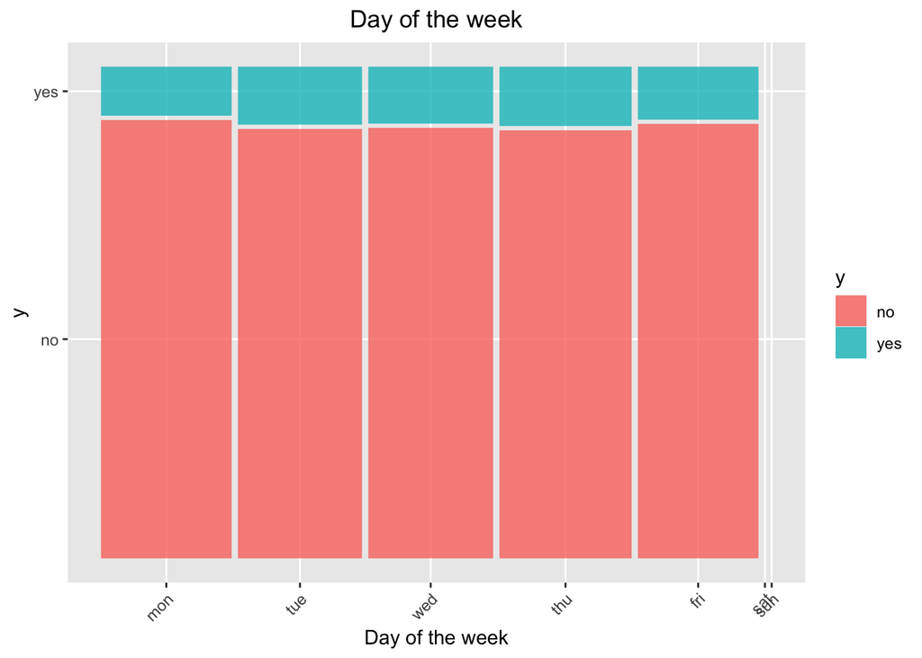

```r
ggplot(Bank_Data) +
  geom_mosaic(aes(x = product(y, day_of_week), fill = y)) +labs(title="Day of the week",x="Day of the week")+theme(plot.title = element_text(hjust = 0.5), axis.text.x = element_text(angle = 45, hjust = 1))
```

It is observed that weekend days are not used for making calls. Results tend to be better on Thursdays.

#### 4. Duration

```r
Bank_Data<-Bank_Data %>% select(-duration)
```

Before a call is made, the duration is not known. Y is also known after the call ends. As a result, it is discarded.

## Other Attributes

#### 1. Campaign

```r
table(bank_data$campaign)
```

```
##
##     1     2     3     4     5     6     7     8     9    10    11    12    13
## 17642 10570  5341  2651  1599   979   629   400   283   225   177   125    92
##    14    15    16    17    18    19    20    21    22    23    24    25    26
##    69    51    51    58    33    26    30    24    17    16    15     8     8
##    27    28    29    30    31    32    33    34    35    37    39    40    41
##    11     8    10     7     7     4     4     3     5     1     1     2     1
##    42    43    56
##     2     2     1
```

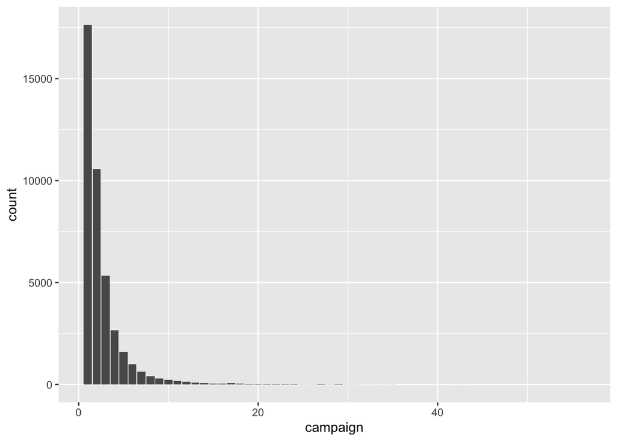

```r
ggplot(bank_data) + aes(x = campaign) +geom_bar()
```

A numerical campaign was converted to a categorical campaign. During a single marketing campaign, calling the same person more than 6-7 times seems excessive

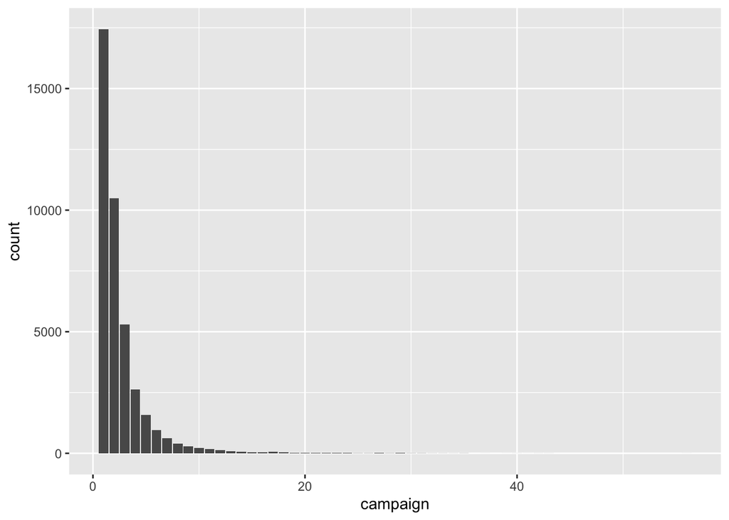

```r
ggplot(Bank_Data) + aes(x = campaign) +geom_bar()
```

```r
#Converting campaign from continuous to categorical
Bank_Data<-Bank_Data %>% filter(campaign<=7)
table(Bank_Data$campaign)
```

```
##
##     1     2     3     4     5     6     7
## 17444 10485  5291  2626  1586   966   621
```

```r
CrossTable(Bank_Data$campaign,Bank_Data$y)
```

```
##
##
##    Cell Contents
## |-------------------------|
## |                       N |
## | Chi-square contribution |
## |           N / Row Total |
## |           N / Col Total |
## |         N / Table Total |
## |-------------------------|
##
##
## Total Observations in Table:  39019
##
##
##                    | Bank_Data$y
## Bank_Data$campaign |        no |       yes | Row Total |
## -------------------|-----------|-----------|-----------|
##                  1 |     15176 |      2268 |     17444 |
##                    |     3.964 |    30.257 |           |
##                    |     0.870 |     0.130 |     0.447 |
##                    |     0.440 |     0.502 |           |
##                    |     0.389 |     0.058 |           |
## -------------------|-----------|-----------|-----------|
##                  2 |      9280 |      1205 |     10485 |
##                    |     0.010 |     0.076 |           |
##                    |     0.885 |     0.115 |     0.269 |
##                    |     0.269 |     0.267 |           |
##                    |     0.238 |     0.031 |           |
## -------------------|-----------|-----------|-----------|
##                  3 |      4722 |       569 |      5291 |
##                    |     0.412 |     3.146 |           |
##                    |     0.892 |     0.108 |     0.136 |
##                    |     0.137 |     0.126 |           |
##                    |     0.121 |     0.015 |           |
## -------------------|-----------|-----------|-----------|
##                  4 |      2380 |       246 |      2626 |
##                    |     1.459 |    11.134 |           |
##                    |     0.906 |     0.094 |     0.067 |
##                    |     0.069 |     0.054 |           |
```

[output cut: 10 more lines]

```
##                    |     0.923 |     0.077 |     0.025 |
##                    |     0.026 |     0.016 |           |
##                    |     0.023 |     0.002 |           |
## -------------------|-----------|-----------|-----------|
##                  7 |       583 |        38 |       621 |
##                    |     2.098 |    16.010 |           |
##                    |     0.939 |     0.061 |     0.016 |
##                    |     0.017 |     0.008 |           |
##                    |     0.015 |     0.001 |           |
## -------------------|-----------|-----------|-----------|
##       Column Total |     34499 |      4520 |     39019 |
##                    |     0.884 |     0.116 |           |
## -------------------|-----------|-----------|-----------|
##
##
```

```r
chisq.test(Bank_Data$campaign,Bank_Data$y)
```

```
##
##  Pearson's Chi-squared test
##
## data:  Bank_Data$campaign and Bank_Data$y
## X-squared = 108.09, df = 6, p-value < 2.2e-16
```

Since p-value is less than 0.05. It can be concluded that variable campaign is significant with the response variable i.e.,y.

#### 2. Pdays

```r
table(bank_data$pdays)
```

```
##
##     0     1     2     3     4     5     6     7     8     9    10    11    12
##    15    26    61   439   118    46   412    60    18    64    52    28    58
##    13    14    15    16    17    18    19    20    21    22    25    26    27
##    36    20    24    11     8     7     3     1     2     3     1     1     1
##   999
## 39673
```

Most of the values have 999. So, pdays are converted from numerical to categorical. If not contacted in pdays then 0(NO) else 1(YES). New column is added called cat_pdays with 0’s and 1’s and the existing column i.e., pdays is discarded.

```r
#New variable
Bank_Data<-Bank_Data %>% mutate(cat_pdays = if_else(pdays == 999, "No", "Yes"))
#Deleting old variable
Bank_Data<-Bank_Data %>% select(-pdays)
table(Bank_Data$cat_pdays)
```

```
##
##    No   Yes
## 37538  1481
```

```r
CrossTable(Bank_Data$cat_pdays,Bank_Data$y)
```

```
##
##
##    Cell Contents
## |-------------------------|
## |                       N |
## | Chi-square contribution |
## |           N / Row Total |
## |           N / Col Total |
## |         N / Table Total |
## |-------------------------|
##
##
## Total Observations in Table:  39019
##
##
##                     | Bank_Data$y
## Bank_Data$cat_pdays |        no |       yes | Row Total |
## --------------------|-----------|-----------|-----------|
##                  No |     33974 |      3564 |     37538 |
##                     |    18.540 |   141.509 |           |
##                     |     0.905 |     0.095 |     0.962 |
##                     |     0.985 |     0.788 |           |
##                     |     0.871 |     0.091 |           |
## --------------------|-----------|-----------|-----------|
##                 Yes |       525 |       956 |      1481 |
##                     |   469.930 |  3586.753 |           |
##                     |     0.354 |     0.646 |     0.038 |
##                     |     0.015 |     0.212 |           |
##                     |     0.013 |     0.025 |           |
## --------------------|-----------|-----------|-----------|
##        Column Total |     34499 |      4520 |     39019 |
##                     |     0.884 |     0.116 |           |
## --------------------|-----------|-----------|-----------|
##
##
```

```r
chisq.test(Bank_Data$cat_pdays,Bank_Data$y)
```

```
##
##  Pearson's Chi-squared test with Yates' continuity correction
##
## data:  Bank_Data$cat_pdays and Bank_Data$y
## X-squared = 4211.4, df = 1, p-value < 2.2e-16
```

Since p-value is less than 0.05. It can be concluded that variable cat_pdays is significant with the response variable i.e., y.

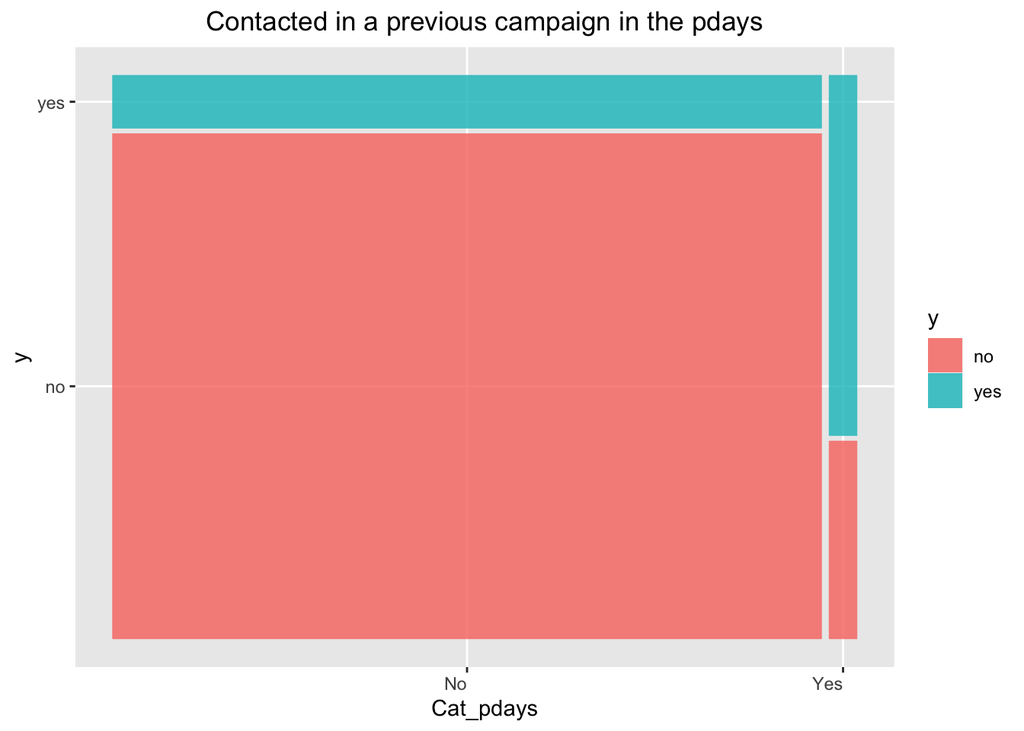

```r
ggplot(Bank_Data) +
  geom_mosaic(aes(x = product(y, cat_pdays), fill = y)) +labs(title="Contacted in a previous campaign in the pdays",x="Cat_pdays")+theme(plot.title = element_text(hjust = 0.5), axis.text.x = element_text(hjust = 1))
```

Recontacting a customer after a prior campaign appears to significantly boost the likelihood of subscribing

#### 3. Previous

```r
table(bank_data$previous)
```

```
##
##     0     1     2     3     4     5     6     7
## 35563  4561   754   216    70    18     5     1
```

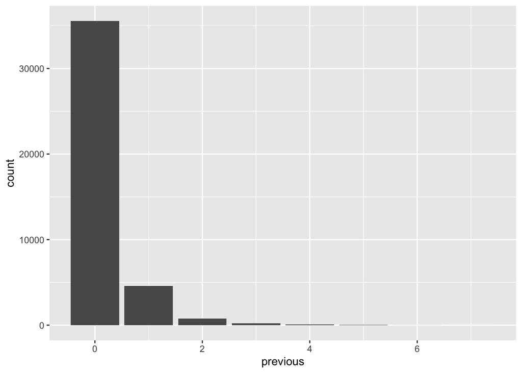

```r
ggplot(bank_data) + aes(x = previous) +geom_bar()
```

```r
Bank_Data<-Bank_Data %>% filter(previous<=2)
table(Bank_Data$previous)
```

```
##
##     0     1     2
## 33507  4471   733
```

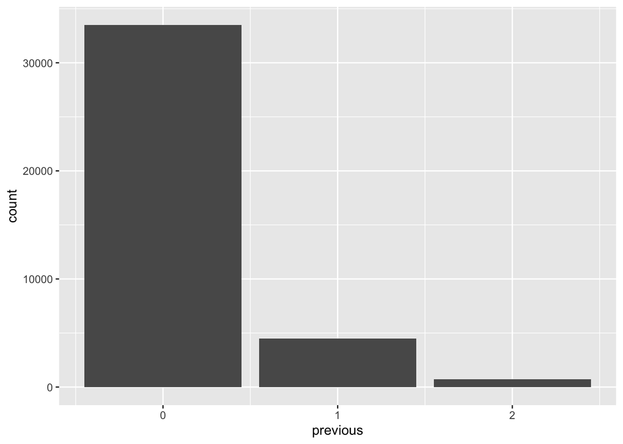

```r
ggplot(Bank_Data) + aes(x = previous) +geom_bar()
```

```r
CrossTable(Bank_Data$previous,Bank_Data$y)
```

```
##
##
##    Cell Contents
## |-------------------------|
## |                       N |
## | Chi-square contribution |
## |           N / Row Total |
## |           N / Col Total |
## |         N / Table Total |
## |-------------------------|
##
##
## Total Observations in Table:  38711
##
##
##                    | Bank_Data$y
## Bank_Data$previous |        no |       yes | Row Total |
## -------------------|-----------|-----------|-----------|
##                  0 |     30464 |      3043 |     33507 |
##                    |    17.073 |   135.245 |           |
##                    |     0.909 |     0.091 |     0.866 |
##                    |     0.886 |     0.701 |           |
##                    |     0.787 |     0.079 |           |
## -------------------|-----------|-----------|-----------|
##                  1 |      3516 |       955 |      4471 |
##                    |    51.888 |   411.038 |           |
##                    |     0.786 |     0.214 |     0.115 |
##                    |     0.102 |     0.220 |           |
##                    |     0.091 |     0.025 |           |
## -------------------|-----------|-----------|-----------|
##                  2 |       392 |       341 |       733 |
##                    |   102.941 |   815.463 |           |
##                    |     0.535 |     0.465 |     0.019 |
##                    |     0.011 |     0.079 |           |
##                    |     0.010 |     0.009 |           |
## -------------------|-----------|-----------|-----------|
##       Column Total |     34372 |      4339 |     38711 |
##                    |     0.888 |     0.112 |           |
## -------------------|-----------|-----------|-----------|
##
##
```

```r
chisq.test(Bank_Data$previous,Bank_Data$y)
```

```
##
##  Pearson's Chi-squared test
##
## data:  Bank_Data$previous and Bank_Data$y
## X-squared = 1533.6, df = 2, p-value < 2.2e-16
```

Since p-value is less than 0.05. It can be concluded that variable previous is significant with the response variable i.e., y.

#### 4. Poutcome

```r
table(Bank_Data$poutcome)
```

```
##
##     failure nonexistent     success
##        4048       33507        1156
```

```r
CrossTable(Bank_Data$poutcome,Bank_Data$y)
```

```
##
##
##    Cell Contents
## |-------------------------|
## |                       N |
## | Chi-square contribution |
## |           N / Row Total |
## |           N / Col Total |
## |         N / Table Total |
## |-------------------------|
##
##
## Total Observations in Table:  38711
##
##
##                    | Bank_Data$y
## Bank_Data$poutcome |        no |       yes | Row Total |
## -------------------|-----------|-----------|-----------|
##            failure |      3496 |       552 |      4048 |
##                    |     2.687 |    21.284 |           |
##                    |     0.864 |     0.136 |     0.105 |
##                    |     0.102 |     0.127 |           |
##                    |     0.090 |     0.014 |           |
## -------------------|-----------|-----------|-----------|
##        nonexistent |     30464 |      3043 |     33507 |
##                    |    17.073 |   135.245 |           |
##                    |     0.909 |     0.091 |     0.866 |
##                    |     0.886 |     0.701 |           |
##                    |     0.787 |     0.079 |           |
## -------------------|-----------|-----------|-----------|
##            success |       412 |       744 |      1156 |
##                    |   367.801 |  2913.588 |           |
##                    |     0.356 |     0.644 |     0.030 |
##                    |     0.012 |     0.171 |           |
##                    |     0.011 |     0.019 |           |
## -------------------|-----------|-----------|-----------|
##       Column Total |     34372 |      4339 |     38711 |
##                    |     0.888 |     0.112 |           |
## -------------------|-----------|-----------|-----------|
##
##
```

```r
chisq.test(Bank_Data$poutcome,Bank_Data$y)
```

```
##
##  Pearson's Chi-squared test
##
## data:  Bank_Data$poutcome and Bank_Data$y
## X-squared = 3457.7, df = 2, p-value < 2.2e-16
```

Since p-value is less than 0.05. It can be concluded that variable Poutcome is significant with the response variable i.e., y.

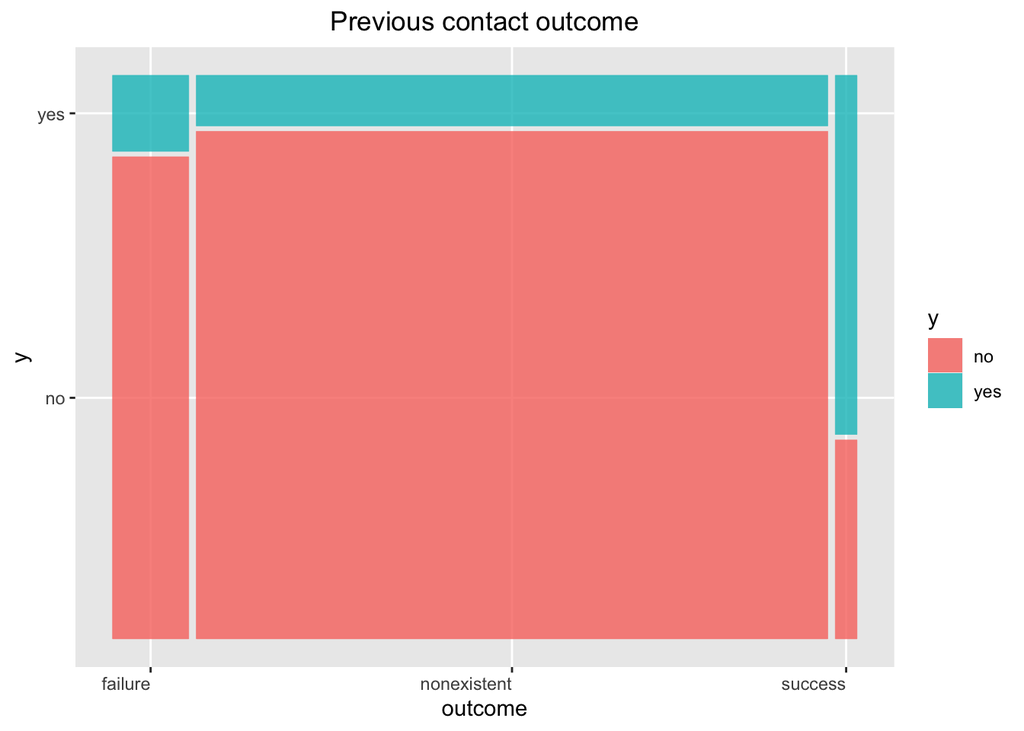

```r
ggplot(Bank_Data) +
  geom_mosaic(aes(x = product(y, poutcome), fill = y)) +labs(title="Previous contact outcome",x="outcome")+theme(plot.title = element_text(hjust = 0.5), axis.text.x = element_text( hjust = 1))
```

Almost 64.4% of people who previously subscribed to a term deposit have agreed to do so again. Therefore, it is important to recontact people.

## Social - Economical context attributes

The five continuous variables are indicators of social and economic conditions. They are Variation in employment rate, Consumer price index, Consumer confidence index, Euribor 3 months rate, Number of employees. The correlation between these variables is calculated and plotted.

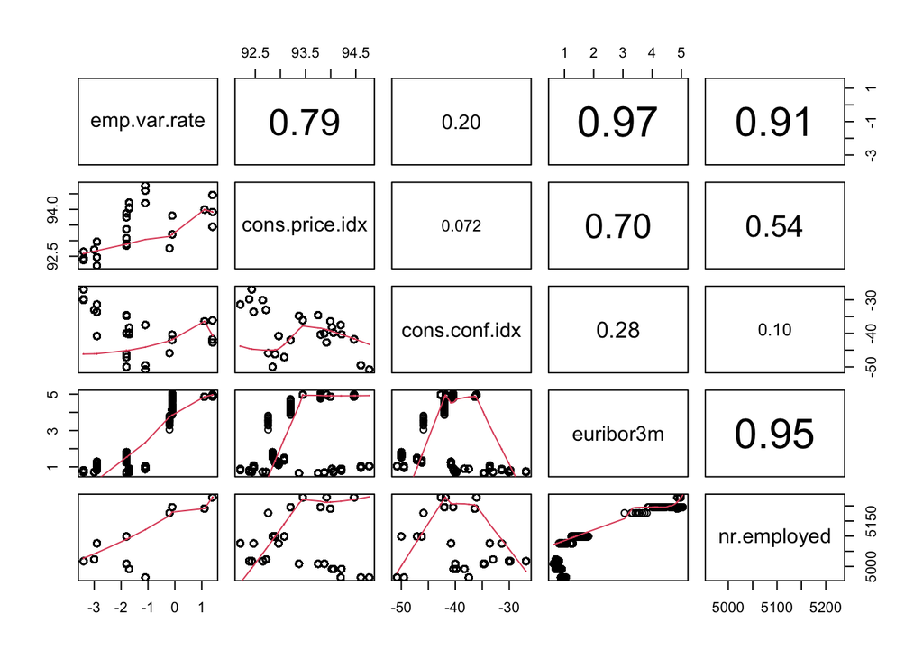

```r
# Function to add correlation coefficients
panel.cor <- function(x, y, digits = 2, prefix = "", cex.cor, ...) {
    usr <- par("usr")
    on.exit(par(usr))
    par(usr = c(0, 1, 0, 1))
    Cor <- abs(cor(x, y))
    txt <- paste0(prefix, format(c(Cor, 0.123456789), digits = digits)[1])
    if(missing(cex.cor)) {
        cex.cor <- 0.4 / strwidth(txt)
    }
    text(0.5, 0.5, txt,
         cex = 1 + cex.cor * Cor)
}

# Plotting the correlation matrix
plot(Bank_Data[,11:15],
      upper.panel = panel.cor,
      lower.panel = panel.smooth)
```

More than 0.90 correlation coefficients were found in three pairs, which is far too high. Emp.var.rate is not significant. In order to soften the correlations between those five variables (see Fig 3.15), this variable is discarded. While two variables, euribor 3m and nr.employed, still show a strong correlation of 95%, these variables are retained. Due to the fact that the number of employees is not related to the euribor 3 months rate, this is most likely a misleading association.

```r
Bank_Data<-Bank_Data %>% select(-emp.var.rate)
```

```r
#t.test(Bank_Data$emp.var.rate~Bank_Data$y)
t.test(Bank_Data$cons.price.idx~Bank_Data$y)
```

```
##
##  Welch Two Sample t-test
##
## data:  Bank_Data$cons.price.idx by Bank_Data$y
## t = 24.914, df = 5129.9, p-value < 2.2e-16
## alternative hypothesis: true difference in means between group no and group yes is not equal to 0
## 95 percent confidence interval:
##  0.2432471 0.2847972
## sample estimates:
##  mean in group no mean in group yes
##          93.59021          93.32619
```

```r
t.test(Bank_Data$cons.conf.idx~Bank_Data$y)
```

```
##
##  Welch Two Sample t-test
##
## data:  Bank_Data$cons.conf.idx by Bank_Data$y
## t = -8.1332, df = 4910.9, p-value = 5.25e-16
## alternative hypothesis: true difference in means between group no and group yes is not equal to 0
## 95 percent confidence interval:
##  -0.9782358 -0.5982372
## sample estimates:
##  mean in group no mean in group yes
##         -40.61108         -39.82284
```

```r
t.test(Bank_Data$euribor3m~Bank_Data$y)
```

```
##
##  Welch Two Sample t-test
##
## data:  Bank_Data$euribor3m by Bank_Data$y
## t = 59.063, df = 5361.4, p-value < 2.2e-16
## alternative hypothesis: true difference in means between group no and group yes is not equal to 0
## 95 percent confidence interval:
##  1.591484 1.700760
## sample estimates:
##  mean in group no mean in group yes
##          3.787124          2.141002
```

```r
t.test(Bank_Data$nr.employed~Bank_Data$y)
```

```
##
##  Welch Two Sample t-test
##
## data:  Bank_Data$nr.employed by Bank_Data$y
## t = 57.46, df = 4965.1, p-value < 2.2e-16
## alternative hypothesis: true difference in means between group no and group yes is not equal to 0
## 95 percent confidence interval:
##  75.03565 80.33669
## sample estimates:
##  mean in group no mean in group yes
##          5175.396          5097.710
```

From the Welch two sample t-test it can be seen that all other variables in social-economical context are significant with the response variable.

```r
#np1<-ggplot(Bank_Data, aes(x=y, y=emp.var.rate, fill=y)) +
 # geom_boxplot()
np2<-ggplot(Bank_Data, aes(x=y, y=cons.price.idx, fill=y)) +
  geom_boxplot()
np3<-ggplot(Bank_Data, aes(x=y, y=cons.conf.idx, fill=y)) +
  geom_boxplot()
np4<-ggplot(Bank_Data, aes(x=y, y=euribor3m, fill=y)) +
  geom_boxplot()
np5<-ggplot(Bank_Data, aes(x=y, y=nr.employed, fill=y)) +
  geom_boxplot()
ggplot_build(np2)$data
```

```
## [[1]]
##      fill   ymin  lower middle  upper   ymax outliers notchupper notchlower x
## 1 #F8766D 92.201 93.075 93.918 93.994 94.767            93.92583   93.91017 1
## 2 #00BFC4 92.201 92.893 93.075 93.918 94.767            93.09959   93.05041 2
##   flipped_aes PANEL group ymin_final ymax_final  xmin  xmax xid newx new_width
## 1       FALSE     1     1     92.201     94.767 0.625 1.375   1    1      0.75
## 2       FALSE     1     2     92.201     94.767 1.625 2.375   2    2      0.75
##   weight colour size alpha shape linetype
## 1      1 grey20  0.5    NA    19    solid
## 2      1 grey20  0.5    NA    19    solid
```

```r
ggplot_build(np3)$data
```

[output not shown]

```r
ggplot_build(np4)$data
```

```
## [[1]]
##      fill  ymin lower middle upper  ymax outliers notchupper notchlower x
## 1 #F8766D 0.634 1.405  4.857 4.961 5.045            4.887305   4.826695 1
## 2 #00BFC4 0.634 0.854  1.268 4.533 5.045            1.356245   1.179755 2
##   flipped_aes PANEL group ymin_final ymax_final  xmin  xmax xid newx new_width
## 1       FALSE     1     1      0.634      5.045 0.625 1.375   1    1      0.75
## 2       FALSE     1     2      0.634      5.045 1.625 2.375   2    2      0.75
##   weight colour size alpha shape linetype
## 1      1 grey20  0.5    NA    19    solid
## 2      1 grey20  0.5    NA    19    solid
```

```r
ggplot_build(np5)$data
```

```
## [[1]]
##      fill   ymin  lower middle  upper   ymax outliers notchupper notchlower x
## 1 #F8766D 4963.6 5099.1 5195.8 5228.1 5228.1            5196.899   5194.701 1
## 2 #00BFC4 4963.6 5017.5 5099.1 5191.0 5228.1            5103.262   5094.938 2
##   flipped_aes PANEL group ymin_final ymax_final  xmin  xmax xid newx new_width
## 1       FALSE     1     1     4963.6     5228.1 0.625 1.375   1    1      0.75
## 2       FALSE     1     2     4963.6     5228.1 1.625 2.375   2    2      0.75
##   weight colour size alpha shape linetype
## 1      1 grey20  0.5    NA    19    solid
## 2      1 grey20  0.5    NA    19    solid
```

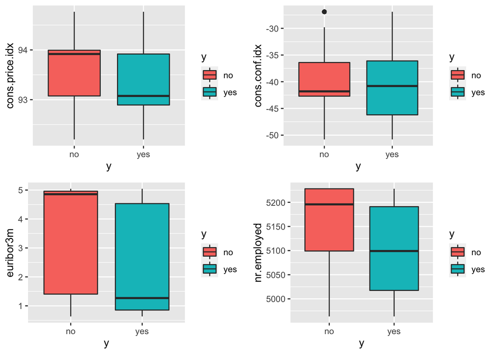

```r
plot_grid(np2,np3,np4,np5,ncol=2)
```

#### Reordering Dataset

```r
Bank_Data <- Bank_Data[, c(1,2,3,4,5,6,7,8,16,9,10,11,12,13,14,15)]
```

#### Cleaned dataset

```r
dim(Bank_Data)
```

```
## [1] 38711    16
```

```r
str(Bank_Data)
```

```
## 'data.frame':    38711 obs. of  16 variables:
##  $ age           : chr  "Middle_aged" "Middle_aged" "Middle_aged" "Middle_aged" ...
##  $ job           : chr  "housemaid" "services" "services" "admin." ...
##  $ marital       : chr  "married" "married" "married" "married" ...
##  $ education     : chr  "basic.4y" "high.school" "high.school" "basic.6y" ...
##  $ contact       : chr  "telephone" "telephone" "telephone" "telephone" ...
##  $ month         : Factor w/ 12 levels "jan","feb","mar",..: 5 5 5 5 5 5 5 5 5 5 ...
##  $ day_of_week   : Factor w/ 7 levels "mon","tue","wed",..: 1 1 1 1 1 1 1 1 1 1 ...
##  $ campaign      : int  1 1 1 1 1 1 1 1 1 1 ...
##  $ cat_pdays     : chr  "No" "No" "No" "No" ...
##  $ previous      : int  0 0 0 0 0 0 0 0 0 0 ...
##  $ poutcome      : chr  "nonexistent" "nonexistent" "nonexistent" "nonexistent" ...
##  $ cons.price.idx: num  94 94 94 94 94 ...
##  $ cons.conf.idx : num  -36.4 -36.4 -36.4 -36.4 -36.4 -36.4 -36.4 -36.4 -36.4 -36.4 ...
##  $ euribor3m     : num  4.86 4.86 4.86 4.86 4.86 ...
##  $ nr.employed   : num  5191 5191 5191 5191 5191 ...
##  $ y             : chr  "no" "no" "no" "no" ...
```

```r
#Unknowns
colSums(Bank_Data == "unknown")
```

```
##            age            job        marital      education        contact
##              0              0              0              0              0
##          month    day_of_week       campaign      cat_pdays       previous
##              0              0              0              0              0
##       poutcome cons.price.idx  cons.conf.idx      euribor3m    nr.employed
##              0              0              0              0              0
##              y
##              0
```

```r
sum(Bank_Data == "unknown")
```

```
## [1] 0
```

```r
unknowns<-Bank_Data %>%
  summarise_all(list(~sum(. == "unknown"))) %>%
  gather(key = "Variables", value = "Number_of_Unknowns") %>%
  arrange(-Number_of_Unknowns)
unknowns
```

```
##         Variables Number_of_Unknowns
## 1             age                  0
## 2             job                  0
## 3         marital                  0
## 4       education                  0
## 5         contact                  0
## 6           month                  0
## 7     day_of_week                  0
## 8        campaign                  0
## 9       cat_pdays                  0
## 10       previous                  0
## 11       poutcome                  0
## 12 cons.price.idx                  0
## 13  cons.conf.idx                  0
## 14      euribor3m                  0
## 15    nr.employed                  0
## 16              y                  0
```

```r
#Changing response no to 0 and yes to 1
Bank_Data<-Bank_Data %>% mutate(y = factor(if_else(y == "no", 0, 1),levels = c(0, 1)))
```

```r
 # Convert all char columns to factor
Bank_Data_1 <- as.data.frame(unclass(Bank_Data),stringsAsFactors = TRUE)
str(Bank_Data_1)
```

```
## 'data.frame':    38711 obs. of  16 variables:
##  $ age           : Factor w/ 3 levels "Middle_aged",..: 1 1 1 1 1 1 1 1 3 3 ...
##  $ job           : Factor w/ 11 levels "admin.","blue-collar",..: 4 8 8 1 8 8 1 2 10 8 ...
##  $ marital       : Factor w/ 3 levels "divorced","married",..: 2 2 2 2 2 2 2 2 3 3 ...
##  $ education     : Factor w/ 6 levels "basic.4y","basic.6y",..: 1 4 4 2 4 3 5 6 5 4 ...
##  $ contact       : Factor w/ 2 levels "cellular","telephone": 2 2 2 2 2 2 2 2 2 2 ...
##  $ month         : Factor w/ 12 levels "jan","feb","mar",..: 5 5 5 5 5 5 5 5 5 5 ...
##  $ day_of_week   : Factor w/ 7 levels "mon","tue","wed",..: 1 1 1 1 1 1 1 1 1 1 ...
##  $ campaign      : int  1 1 1 1 1 1 1 1 1 1 ...
##  $ cat_pdays     : Factor w/ 2 levels "No","Yes": 1 1 1 1 1 1 1 1 1 1 ...
##  $ previous      : int  0 0 0 0 0 0 0 0 0 0 ...
##  $ poutcome      : Factor w/ 3 levels "failure","nonexistent",..: 2 2 2 2 2 2 2 2 2 2 ...
##  $ cons.price.idx: num  94 94 94 94 94 ...
##  $ cons.conf.idx : num  -36.4 -36.4 -36.4 -36.4 -36.4 -36.4 -36.4 -36.4 -36.4 -36.4 ...
##  $ euribor3m     : num  4.86 4.86 4.86 4.86 4.86 ...
##  $ nr.employed   : num  5191 5191 5191 5191 5191 ...
##  $ y             : Factor w/ 2 levels "0","1": 1 1 1 1 1 1 1 1 1 1 ...
```

Rejected variables : Five variables are rejected. A lack of variability in default, a lack of significance in housing, a lack of significance in loans, a meaninglessness in duration, and a lack of significance in variation in employment rate.

Accepted variables : It is necessary to transform every character variable into a factor variable in order to interpret it. Finally, there are 15 predictors and 1 response variable without missing values.

## Model Implementation

Splitting a data set into training and testing sets is known as data splicing. The data is split 80:20, so that 80% of the data is used for training and 20% for testing the model; this was done using the random samples and permutation function sample() in R.

```r
set.seed(123)
s <- sample(nrow(Bank_Data_1),nrow(Bank_Data_1)*.8)
Bank_Data_Train <- Bank_Data_1[s,]
Bank_Data_Test <- Bank_Data_1[-s,]
```

->Linear algorithms: Logistic Regression. ->Nonlinear algorithms: Naïve Bayes. ->Bagging algorithms: Random Forest.

##### Linear algorithms: Logistic Regression.

Logistic Regression Model 1 : Fitted for the entire cleaned dataset.

```r
LogR1 <- glm(y ~., family=binomial(link='logit'), data=Bank_Data_Train)

summary(LogR1)
```

```
##
## Call:
## glm(formula = y ~ ., family = binomial(link = "logit"), data = Bank_Data_Train)
##
## Deviance Residuals:
##     Min       1Q   Median       3Q      Max
## -2.2267  -0.4013  -0.3305  -0.2630   2.7998
##
## Coefficients:
##                               Estimate Std. Error z value Pr(>|z|)
## (Intercept)                  94.966805  25.064273   3.789 0.000151 ***
## ageOld_aged                   0.259477   0.122581   2.117 0.034278 *
## ageYoung_aged                 0.108043   0.061209   1.765 0.077540 .
## jobblue-collar               -0.145967   0.076660  -1.904 0.056900 .
## jobentrepreneur              -0.068497   0.122815  -0.558 0.577031
## jobhousemaid                 -0.064745   0.146494  -0.442 0.658515
## jobmanagement                -0.030585   0.085726  -0.357 0.721260
## jobretired                    0.162942   0.115412   1.412 0.158001
## jobself-employed             -0.091821   0.117706  -0.780 0.435340
## jobservices                  -0.116780   0.084183  -1.387 0.165375
## jobstudent                    0.174516   0.113381   1.539 0.123756
## jobtechnician                 0.011671   0.070109   0.166 0.867790
## jobunemployed                -0.048816   0.126746  -0.385 0.700129
## maritalmarried                0.019554   0.068132   0.287 0.774105
## maritalsingle                 0.060650   0.076075   0.797 0.425317
## educationbasic.6y             0.090414   0.118228   0.765 0.444425
## educationbasic.9y            -0.077195   0.093320  -0.827 0.408120
## educationhigh.school          0.068466   0.090344   0.758 0.448551
## educationprofessional.course  0.056362   0.100087   0.563 0.573347
## educationuniversity.degree    0.098985   0.088076   1.124 0.261072
## contacttelephone             -0.533973   0.069354  -7.699 1.37e-14 ***
## monthapr                     -0.734472   0.132382  -5.548 2.89e-08 ***
## monthmay                     -1.435425   0.121282 -11.835  < 2e-16 ***
## monthjun                     -0.433547   0.146536  -2.959 0.003090 **
## monthjul                     -0.617212   0.135079  -4.569 4.89e-06 ***
## monthaug                     -0.985622   0.135398  -7.279 3.35e-13 ***
## monthsep                     -1.407262   0.166207  -8.467  < 2e-16 ***
## monthoct                     -1.017031   0.155838  -6.526 6.75e-11 ***
## monthnov                     -1.206819   0.131679  -9.165  < 2e-16 ***
## monthdec                     -0.596799   0.220285  -2.709 0.006744 **
```

[output cut: 8 more lines]

```
## poutcomesuccess               0.789054   0.280200   2.816 0.004862 **
## cons.price.idx               -0.233017   0.138357  -1.684 0.092149 .
## cons.conf.idx                 0.008615   0.008036   1.072 0.283672
## euribor3m                     0.204881   0.134649   1.522 0.128110
## nr.employed                  -0.014611   0.002580  -5.663 1.48e-08 ***
## ---
## Signif. codes:  0 '***' 0.001 '**' 0.01 '*' 0.05 '.' 0.1 ' ' 1
##
## (Dispersion parameter for binomial family taken to be 1)
##
##     Null deviance: 21895  on 30967  degrees of freedom
## Residual deviance: 17471  on 30925  degrees of freedom
## AIC: 17557
##
## Number of Fisher Scoring iterations: 6
```

Regression models can be simplified by eliminating insignificant terms. It is easier to work with a model if the number of terms is reduced. A model with insignificant terms can reduce the precision of the predictors if they are left in the model. So, model 2 is developed where the model 1 is reduced to significant predictors.

Logistic Regression Model 2 : Reduced model.

```r
LogR2 <- glm(y ~ age + contact + month +day_of_week+cat_pdays + poutcome+ nr.employed, family=binomial(link='logit'), data=Bank_Data_Train)

summary(LogR2)
```

```
##
## Call:
## glm(formula = y ~ age + contact + month + day_of_week + cat_pdays +
##     poutcome + nr.employed, family = binomial(link = "logit"),
##     data = Bank_Data_Train)
##
## Deviance Residuals:
##     Min       1Q   Median       3Q      Max
## -2.1780  -0.3964  -0.3381  -0.2461   2.7821
##
## Coefficients:
##                       Estimate Std. Error z value Pr(>|z|)
## (Intercept)         55.9295534  1.7010369  32.880  < 2e-16 ***
## ageOld_aged          0.3807619  0.0922969   4.125 3.70e-05 ***
## ageYoung_aged        0.1650518  0.0533939   3.091  0.00199 **
## contacttelephone    -0.4963491  0.0574531  -8.639  < 2e-16 ***
## monthapr            -0.8756932  0.1198878  -7.304 2.79e-13 ***
## monthmay            -1.5413479  0.1144890 -13.463  < 2e-16 ***
## monthjun            -0.5452852  0.1240738  -4.395 1.11e-05 ***
## monthjul            -0.6686275  0.1233858  -5.419 5.99e-08 ***
## monthaug            -0.8158432  0.1221457  -6.679 2.40e-11 ***
## monthsep            -1.1998422  0.1530669  -7.839 4.55e-15 ***
## monthoct            -0.8026928  0.1434966  -5.594 2.22e-08 ***
## monthnov            -1.0964711  0.1269559  -8.637  < 2e-16 ***
## monthdec            -0.4015104  0.2142048  -1.874  0.06087 .
## day_of_weektue       0.3288295  0.0645135   5.097 3.45e-07 ***
## day_of_weekwed       0.3670810  0.0648740   5.658 1.53e-08 ***
## day_of_weekthu       0.3047630  0.0632923   4.815 1.47e-06 ***
## day_of_weekfri       0.2795046  0.0656667   4.256 2.08e-05 ***
## cat_pdaysYes         1.0697597  0.2617830   4.086 4.38e-05 ***
## poutcomenonexistent  0.5115671  0.0635522   8.050 8.31e-16 ***
## poutcomesuccess      0.8210450  0.2658216   3.089  0.00201 **
## nr.employed         -0.0112218  0.0003372 -33.282  < 2e-16 ***
## ---
## Signif. codes:  0 '***' 0.001 '**' 0.01 '*' 0.05 '.' 0.1 ' ' 1
##
## (Dispersion parameter for binomial family taken to be 1)
##
##     Null deviance: 21895  on 30967  degrees of freedom
## Residual deviance: 17526  on 30947  degrees of freedom
## AIC: 17568
##
## Number of Fisher Scoring iterations: 6
```

For comparing two models Model 1 and Model 2 ANOVA test is performed. In R ANOVA test is performed using anova(model 1, model 2) function.

```r
anova(LogR1,LogR2,test = "Chisq")
```

```
## Analysis of Deviance Table
##
## Model 1: y ~ age + job + marital + education + contact + month + day_of_week +
##     campaign + cat_pdays + previous + poutcome + cons.price.idx +
##     cons.conf.idx + euribor3m + nr.employed
## Model 2: y ~ age + contact + month + day_of_week + cat_pdays + poutcome +
##     nr.employed
##   Resid. Df Resid. Dev  Df Deviance  Pr(>Chi)
## 1     30925      17471
## 2     30947      17526 -22   -55.44 0.0001028 ***
## ---
## Signif. codes:  0 '***' 0.001 '**' 0.01 '*' 0.05 '.' 0.1 ' ' 1
```

AIC is less for model 1. And also in anova test we reject the null hypo and conclude Model 1 is better.

```r
logistic_train_score = predict(LogR1,Bank_Data_Train,type = "response")
logistic_train_score_pred <- factor(ifelse(logistic_train_score < .5, 0,1))
ltrptr<-confusionMatrix(logistic_train_score_pred,Bank_Data_Train$y,positive="1", mode = "everything")


logistic_test_score = predict(LogR1,newdata = Bank_Data_Test,type = "response")
logistic_test_score_pred <- factor(ifelse(logistic_test_score < .5,0,1))
ltrpte<-confusionMatrix(logistic_test_score_pred,Bank_Data_Test$y,positive="1", mode = "everything")
ltrpte
```

```
## Confusion Matrix and Statistics
##
##           Reference
## Prediction    0    1
##          0 6809  648
##          1  106  180
##
##                Accuracy : 0.9026
##                  95% CI : (0.8958, 0.9091)
##     No Information Rate : 0.8931
##     P-Value [Acc > NIR] : 0.003123
##
##                   Kappa : 0.2838
##
##  Mcnemar's Test P-Value : < 2.2e-16
##
##             Sensitivity : 0.21739
##             Specificity : 0.98467
##          Pos Pred Value : 0.62937
##          Neg Pred Value : 0.91310
##               Precision : 0.62937
##                  Recall : 0.21739
##                      F1 : 0.32316
##              Prevalence : 0.10694
##          Detection Rate : 0.02325
##    Detection Prevalence : 0.03694
##       Balanced Accuracy : 0.60103
##
##        'Positive' Class : 1
##
```

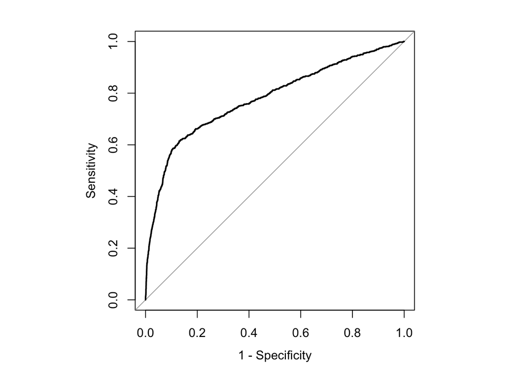

```
##
## Call:
## roc.default(response = Bank_Data_Test$y, predictor = logistic_test_score,     plot = TRUE, legacy.axes = TRUE)
##
## Data: logistic_test_score in 6915 controls (Bank_Data_Test$y 0) < 828 cases (Bank_Data_Test$y 1).
## Area under the curve: 0.7787
```

```r
par(pty="s")
roc(Bank_Data_Test$y,logistic_test_score,plot=TRUE,legacy.axes=TRUE)
```

```r
par(pty="m")
```

Here, the predicted accuracy of the logistic regression model is 90.2% and the misclassification rate is 0.09737828. The area under the curve is 0.7787.

```r
# rocplot <- function(pred, truth, ...) {
#   predob = prediction(pred, truth)
#   perf = performance(predob, "tpr", "fpr")
#   plot(perf, ...)
#   area <- auc(truth, pred)
#   area <- format(round(area, 4), nsmall = 4)
#   text(x=0.8, y=0.1, labels = paste("AUC =", area))
#
#   # the reference x=y line
#   segments(x0=0, y0=0, x1=1, y1=1, col="gray", lty=2)
# }
#
# rocplot(logistic_test_score, Bank_Data_Test$y, col="blue")
```

#### Nonlinear algorithms: Naïve Bayes.

```r
x<-Bank_Data_Train[,-16]
y<-Bank_Data_Train$y
Nb<-naive_bayes(y~.,data=Bank_Data_Train,usekernel = T)
Nb
```

```
##
## ================================== Naive Bayes ==================================
##
##  Call:
## naive_bayes.formula(formula = y ~ ., data = Bank_Data_Train,
##     usekernel = T)
##
## ---------------------------------------------------------------------------------
##
## Laplace smoothing: 0
##
## ---------------------------------------------------------------------------------
##
##  A priori probabilities:
##
##         0         1
## 0.8866249 0.1133751
##
## ---------------------------------------------------------------------------------
##
##  Tables:
##
## ---------------------------------------------------------------------------------
##  ::: age (Categorical)
## ---------------------------------------------------------------------------------
##
## age                    0          1
##   Middle_aged 0.85486397 0.71489604
##   Old_aged    0.01325709 0.08686984
##   Young_aged  0.13187894 0.19823412
##
## ---------------------------------------------------------------------------------
##  ::: job (Categorical)
## ---------------------------------------------------------------------------------
##
## job                      0          1
##   admin.        0.25115635 0.28909143
##   blue-collar   0.23848199 0.14240957
##   entrepreneur  0.03685763 0.02620336
##   housemaid     0.02534873 0.02278553
```

[output cut: 27 more lines]

```
##   university.degree   0.32723896 0.40387354
##
## ---------------------------------------------------------------------------------
##  ::: contact (Bernoulli)
## ---------------------------------------------------------------------------------
##
## contact             0         1
##   cellular  0.6146338 0.8319567
##   telephone 0.3853662 0.1680433
##
## ---------------------------------------------------------------------------------
##
## # ... and 10 more tables
##
## ---------------------------------------------------------------------------------
```

```r
#predict-train
Nb_pred_train<-predict(Nb,Bank_Data_Train)
Nb_ptrain_cm<-confusionMatrix(Nb_pred_train,Bank_Data_Train$y,positive="1", mode = "everything")
```

```r
#predict-test
Nb_pred_test<-predict(Nb,Bank_Data_Test)
Nb_ptest_cm<-confusionMatrix(Nb_pred_test,Bank_Data_Test$y,positive="1", mode = "everything")
Nb_ptest_cm
```

```
## Confusion Matrix and Statistics
##
##           Reference
## Prediction    0    1
##          0 6386  431
##          1  529  397
##
##                Accuracy : 0.876
##                  95% CI : (0.8685, 0.8833)
##     No Information Rate : 0.8931
##     P-Value [Acc > NIR] : 0.999999
##
##                   Kappa : 0.383
##
##  Mcnemar's Test P-Value : 0.001744
##
##             Sensitivity : 0.47947
##             Specificity : 0.92350
##          Pos Pred Value : 0.42873
##          Neg Pred Value : 0.93678
##               Precision : 0.42873
##                  Recall : 0.47947
##                      F1 : 0.45268
##              Prevalence : 0.10694
##          Detection Rate : 0.05127
##    Detection Prevalence : 0.11959
##       Balanced Accuracy : 0.70148
##
##        'Positive' Class : 1
##
```

```r
# rocplot <- function(pred, truth, ...) {
#   predob = prediction(pred, truth)
#   perf = performance(predob, "tpr", "fpr")
#   plot(perf, ...)
#   area <- auc(truth, pred)
#   area <- format(round(area, 4), nsmall = 4)
#   text(x=0.8, y=0.1, labels = paste("AUC =", area))
#
#   # the reference x=y line
#   segments(x0=0, y0=0, x1=1, y1=1, col="gray", lty=2)
# }

#rocplot(Nb_pred_test, Bank_Data_Test$y, col="blue")
```

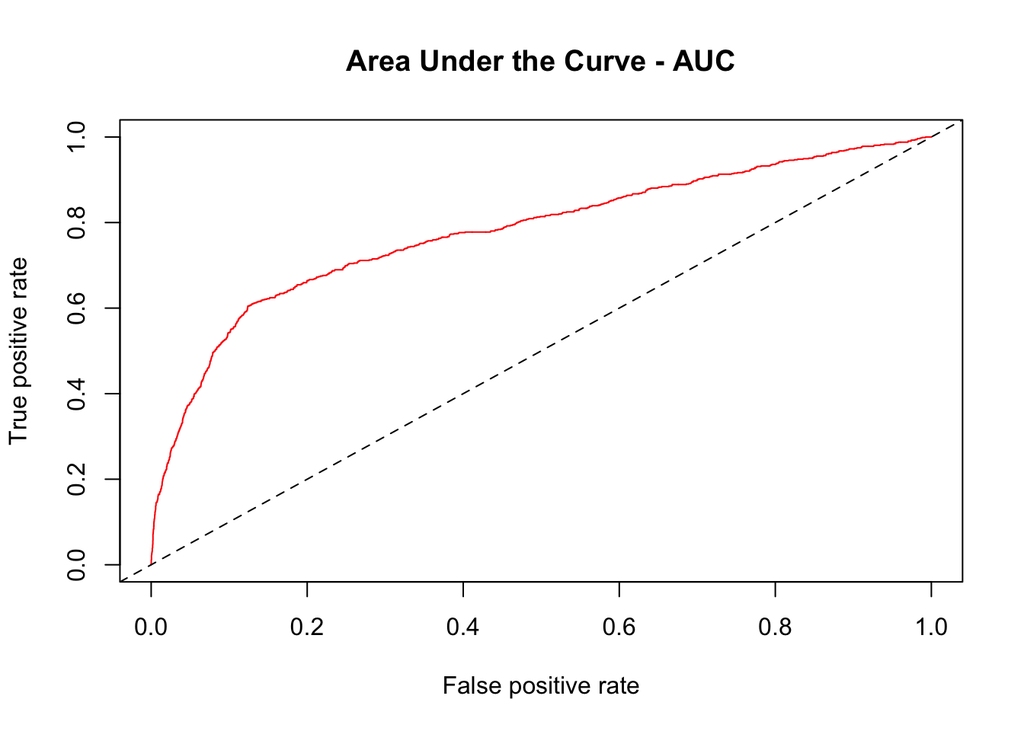

```r
#Plotting AUC
nb_prob <- predict(Nb, type ='prob', Bank_Data_Test)
nb_probs <- prediction(nb_prob[,2], Bank_Data_Test$y)
plot(performance(nb_probs, "tpr", "fpr"), col = "red", main = "Area Under the Curve - AUC")
abline(0,1, lty = 8, col = "black")
```

```r
auc <- performance(nb_probs, "auc")
v_auc <- slot(auc, "y.values")[[1]]
v_auc
```

```
## [1] 0.7781189
```

Here, the predicted accuracy of the naive bayes model is 87.6% and the misclassification rate is 0.123983. The area under the curve is 0.7781189